# Repro Rese Assignment 1

graspa1511

January 11, 2016

I’ll describe step by step my first Reproductible Research Assignment

1. Let’s Load and Process the data:

```r
# Load the raw activity data
activity_raw <- read.csv("activity.csv", stringsAsFactors=FALSE)

# Process data in various steps
# Transform the date attribute to an actual date format
activity_raw$date <- as.POSIXct(activity_raw$date, format="%Y-%m-%d")

# Compute the weekdays from the date attribute
activity_raw <- data.frame(date=activity_raw$date,
                           weekday=tolower(weekdays(activity_raw$date)),
                           steps=activity_raw$steps,
                           interval=activity_raw$interval)

# Compute the day type (weekend or weekday)
activity_raw <- cbind(activity_raw,
                      daytype=ifelse(activity_raw$weekday == "saturday" |
                                     activity_raw$weekday == "sunday", "weekend",
                                     "weekday"))

# Create the final data.frame
activity <- data.frame(date=activity_raw$date,
                       weekday=activity_raw$weekday,
                       daytype=activity_raw$daytype,
                       interval=activity_raw$interval,
                       steps=activity_raw$steps)

# Clear the workspace
rm(activity_raw)
```

We can display a few rows of activity for overview

```r
head(activity)
```

```
##         date weekday daytype interval steps
## 1 2012-10-01  monday weekday        0    NA
## 2 2012-10-01  monday weekday        5    NA
## 3 2012-10-01  monday weekday       10    NA
## 4 2012-10-01  monday weekday       15    NA
## 5 2012-10-01  monday weekday       20    NA
## 6 2012-10-01  monday weekday       25    NA
```

WHAT IS THE MEAN OF TOTAL NUMBER OF STEPS TAKEN PER DAY

Let’s start by making a histogram of the total nbr of steps taken each day

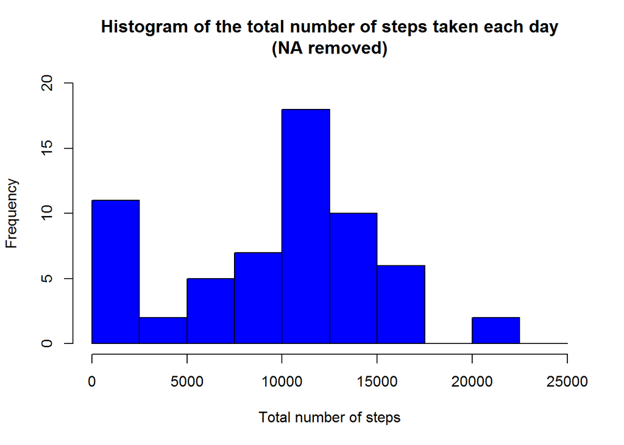

```r
# We start computing the total number of steps each day (NA values removed)
sum_data <- aggregate(activity$steps, by=list(activity$date), FUN=sum, na.rm=TRUE)

# Then we rename the attributes
names(sum_data) <- c("date", "total")

# After that, we compute the histogram of the total number of steps each day
hist(sum_data$total,
     breaks=seq(from=0, to=25000, by=2500),
     col="blue",
     xlab="Total number of steps",
     ylim=c(0, 20),
     main="Histogram of the total number of steps taken each day\n(NA removed)")
```

Finally we calculate and report Mean and Median

```r
# The mean is
mean(sum_data$total)
```

```
## [1] 9354.23
```

```r
#
# The median is
median(sum_data$total)
```

```
## [1] 10395
```

WHAT IS THE AVERAGE DAITLY ACTIVITY PATTERN

Let’s start by making a time series plot

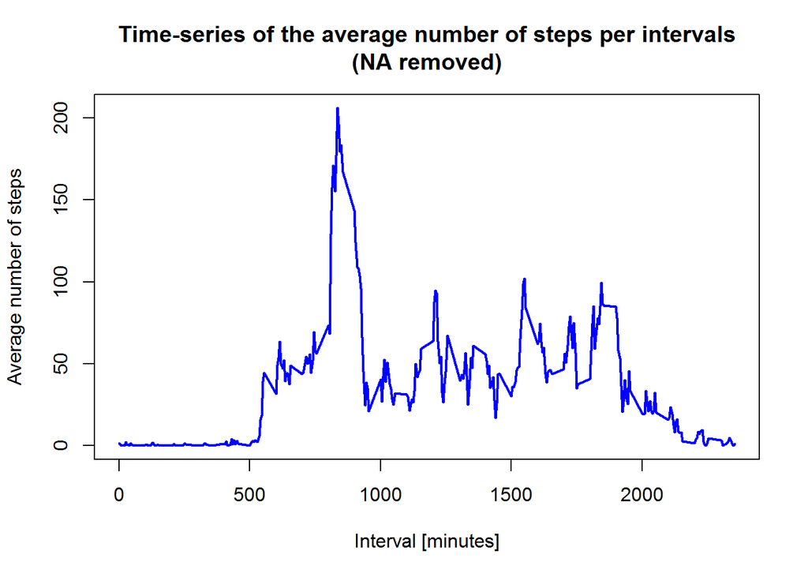

```r
# First let's clear the workspace
rm(sum_data)

# Then let's compute the means of steps accross all days for each interval
mean_data <- aggregate(activity$steps,
                       by=list(activity$interval),
                       FUN=mean,
                       na.rm=TRUE)

# We have to rename the attributes
names(mean_data) <- c("interval", "mean")

# Then we compute the time series plot
plot(mean_data$interval,
     mean_data$mean,
     type="l",
     col="blue",
     lwd=2,
     xlab="Interval [minutes]",
     ylab="Average number of steps",
     main="Time-series of the average number of steps per intervals\n(NA removed)")
```

Which 5-minute interval, on average across all the days in the dataset, contains the maximum number of steps?

```r
# First we find the position of the maximum mean
max_pos <- which(mean_data$mean == max(mean_data$mean))

# Then we lookup the value of interval at this position
max_interval <- mean_data[max_pos, 1]
```

The 5 min interval that contains the max of steps on avg across all days is:

```
## [1] 835
```

INPUTING THE MISSING VALUES DO THE VALUES DIFFER FROM THE ONES SHOWN IN THE BEGINNING OF THE ASSIGNMENT WHAT IS THE IMPACT OF ADDING THE MISSING VALUES

Let’s first calculate and report the total number of missing values in the dataset

```r
# Clear the workspace
rm(max_interval)

# We use the trick that a TRUE boolean value is equivalent to 1 and a FALSE to 0.
NA_count <- sum(is.na(activity$steps))
```

The number of NA is

```
## [1] 2304
```

Then we devise a strategy for filling in all of the missing values in the dataset

```r
# Clear the workspace
rm(NA_count)

# Find the NA positions
na_pos <- which(is.na(activity$steps))

# Create a vector of means
mean_vec <- rep(mean(activity$steps, na.rm=TRUE), times=length(na_pos))
```

We use the strategy to replace each NA by the mean of the steps attribute So finally we create a a new Dataset equal to the original one but with the filled in data

```r
# Replace the NAs by the means
activity[na_pos, "steps"] <- mean_vec

# Clear the workspace
rm(mean_vec, na_pos)
```

We display the first few rows of the new activity data frame

```r
head(activity)
```

```
##         date weekday daytype interval   steps
## 1 2012-10-01  monday weekday        0 37.3826
## 2 2012-10-01  monday weekday        5 37.3826
## 3 2012-10-01  monday weekday       10 37.3826
## 4 2012-10-01  monday weekday       15 37.3826
## 5 2012-10-01  monday weekday       20 37.3826
## 6 2012-10-01  monday weekday       25 37.3826
```

Then we make a histogram of the total number of steps taken each day and calculate and report the mean and median total number of steps taken per day. Do these values differ from the estimates from the first part of the assignment? What is the impact of imputing missing data on the estimates of the total daily number of steps

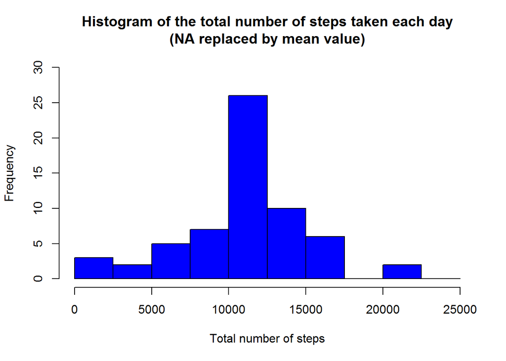

```r
# Compute the total number of steps each day (NA values removed)
sum_data <- aggregate(activity$steps, by=list(activity$date), FUN=sum)

# Rename the attributes
names(sum_data) <- c("date", "total")

# Compute the histogram of the total number of steps each day
hist(sum_data$total,
     breaks=seq(from=0, to=25000, by=2500),
     col="blue",
     xlab="Total number of steps",
     ylim=c(0, 30),
     main="Histogram of the total number of steps taken each day\n(NA replaced by mean value)")
```

Finally we calculate mean and median

```r
# The mean is
mean(sum_data$total)
```

```
## [1] 10766.19
```

```r
# And the median is
median(sum_data$total)
```

```
## [1] 10766.19
```

These values differ a lot compared to the ones estimated in the first part of the assignment. The impact is that we have more data therefore the mean and median both bigger.

ARE THERE DIFFERENCES IN ACTIVITY PATTERNS BETWEEN WEEKDAYS AND WEEKENDS

First let’s create a new factor variable in the dataset with two levels - “weekdays” and “weekend” indicating whether a given date is a weekday or weekend day

```r
# The new factor variable "daytype" was already in the activity data frame
head(activity)
```

```
##         date weekday daytype interval   steps
## 1 2012-10-01  monday weekday        0 37.3826
## 2 2012-10-01  monday weekday        5 37.3826
## 3 2012-10-01  monday weekday       10 37.3826
## 4 2012-10-01  monday weekday       15 37.3826
## 5 2012-10-01  monday weekday       20 37.3826
## 6 2012-10-01  monday weekday       25 37.3826
```

```r
# Clear the workspace
rm(sum_data)

# Load the lattice graphical library
library(lattice)

# Compute the average number of steps taken, averaged across all daytype variable
mean_data <- aggregate(activity$steps,
                       by=list(activity$daytype,
                               activity$weekday, activity$interval), mean)

# Rename the attributes
names(mean_data) <- c("daytype", "weekday", "interval", "mean")
```

Then, let’s display the first few rows of the mean_data data frame

```r
head(mean_data)
```

```
##   daytype  weekday interval     mean
## 1 weekday   friday        0 8.307244
## 2 weekday   monday        0 9.418355
## 3 weekend saturday        0 4.672825
## 4 weekend   sunday        0 4.672825
## 5 weekday thursday        0 9.375844
## 6 weekday  tuesday        0 0.000000
```

After, we compute the time serie plot

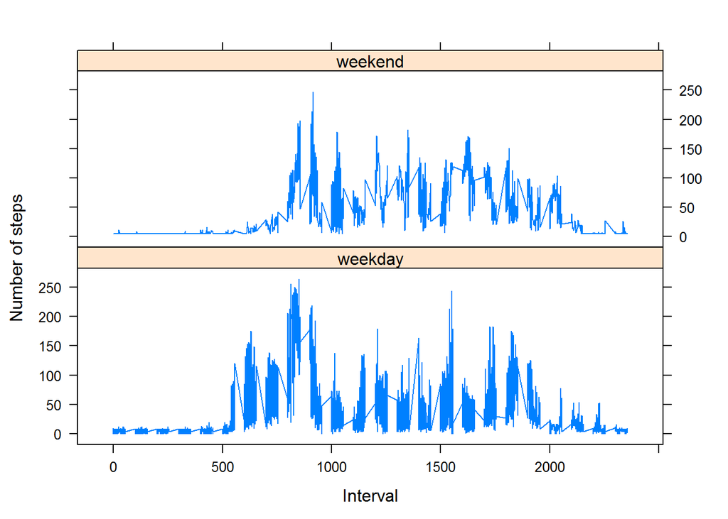

```r
xyplot(mean ~ interval | daytype, mean_data,
       type="l",
       lwd=1,
       xlab="Interval",
       ylab="Number of steps",
       layout=c(1,2))
```

As we can notice from the graph, there are differences in activity patterns.

```r
# Clear the workspace
rm(mean_data)
```